# Nøgletal & stød på konverterbare

Genkørsler af den kalibrerede prisfastsættelsesmotor

Niklas Lehmann Jensen

#### Fra fundet OAS til målte risici

- **Sidst:** motor → diskontér med $z^{\text{swap}}+OAS$ → match markedet → OAS fundet
- **Nu:** genkør den kalibrerede motor under fire kontrollerede stød

| Rentestød | CPR-stød | LYS-stød | OAS-stød |
| --- | --- | --- | --- |
| kurve + adfærd | cash flow direkte | låntagers refi-kurve | investors diskontering |

## Rentestødet

#### Varighed kræver et stød til hele motoren

$$KV\approx-\frac{P_0(+\Delta y)-P_0(-\Delta y)}{2\Delta y\cdot100}$$

| 5% NYK 2053 | Værdi |
| --- | --- |
| $P_0(+15\text{ bp})$ | 101,84 |
| $P_0(-15\text{ bp})$ | 102,27 |
| **KV** | **1,43** |
| **PVBP = KV/100** | **0,0143** |

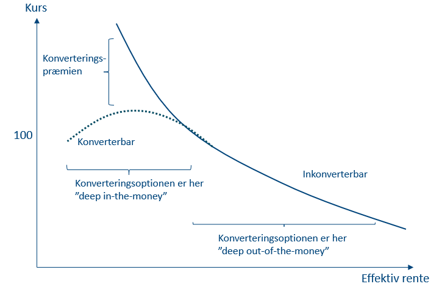

#### Et parallelt rentestød holder kurvens form fast

- Hele swapkurven flyttes **15 bp op eller ned**
- $1\text{ bp}=0{,}0001$ som decimaltal
- LYS og OAS holdes faste; $Gain$, CPR og cash flows genberegnes

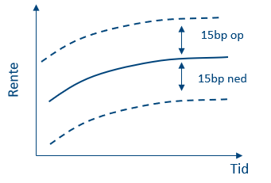

#### Negativ konveksitet vender den normale asymmetri

[figure not shown]

**Indsigt**

Investor er kort call-optionen: kursgevinsten ved rentefald dæmpes, mens kurstabet ved rentestigning ikke dæmpes tilsvarende.

| 15 bp | Ned | Op |
| --- | --- | --- |
| Inkonverterbar | +1,80% | −1,75% |
| Konverterbar | +0,18% | −0,24% |

#### Varighedsled og konveksitet skal bruge samme enhed

$$\Delta P\approx-KV\,\Delta y_{\text{pp}}+\frac12 Cvx_{KR}(\Delta y_{\text{pp}})^2$$

- I denne formel måles $\Delta y_{\text{pp}}$ i **procentpoint**
- 15 bp = 0,15 procentpoint — men 0,0015 i varighedsformlen
- 5% NYK: $\Delta P_{ned}\approx+0{,}18$, $\Delta P_{op}\approx-0{,}25$

## CPR-stødet

#### Over kurs 100 er højere CPR typisk dårligt for investor

| Årlig CPR | Pris | Kronevarighed |
| --- | --- | --- |
| 0% | 120,20 | 15,51 |
| 2% | 110,16 | 7,77 |
| 5% | 105,28 | 4,04 |
| 10% | 102,67 | 2,14 |
| 20% | 101,10 | 1,04 |

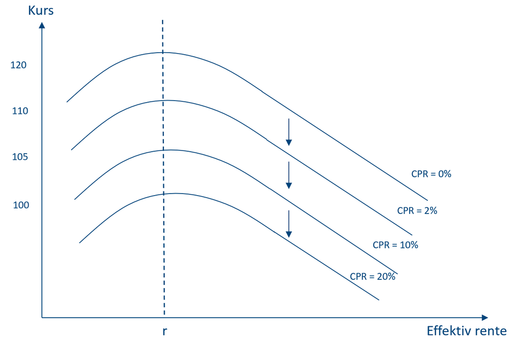

#### Under kurs 100 kan højere CPR løfte prisen

| Årlig CPR | Pris | Kronevarighed |
| --- | --- | --- |
| 0% | 94,36 | 10,69 |
| 2% | 96,48 | 6,02 |
| 5% | 97,83 | 3,44 |
| 10% | 98,60 | 1,94 |
| 20% | 99,07 | 0,98 |

**Indsigt**

Moneyness bestemmer fortegnet: **premium** → pari er et tab; **discount** → pari kan være en gevinst.

#### CPR-stødet isolerer cash flowet — ikke renten

**Faldgrube**

“Høj CPR er dårligt” er ikke en generel regel. Spørg først, om obligationen er over eller under pari.

- Over 100: mere hovedstol indfries til en lavere kurs end markedsværdien
- Under 100: hovedstol kan komme tilbage til en højere kurs end markedsværdien
- I begge tilfælde forkortes betalingsrækken og kronevarigheden falder

## To spread-stød — to sider

#### LYS-stødet rammer låntagers refinansieringsincitament

- Flyt kun refinansieringskurven; hold prisningskurven fast
- $LYS\uparrow\Rightarrow Gain\downarrow\Rightarrow CPR\downarrow$
- Premium-obligation: færre konverteringer kan løfte prisen

| 5% NYK 2053 | $\Delta LYS$ | $\Delta P$ |
| --- | --- | --- |
| DK0009539116 | +100 bp | +2,32 |
| DK0009539116 | −100 bp | −1,04 |

#### OAS-stødet rammer investors diskonteringsspænd

- Hold rentekurve og prepaymentmodel fast
- Flyt kun $OAS$ i $z^{\text{swap}}+OAS$
- Højere diskonteringsrente → lavere modelpris

| 5% NYK 2053 | $\Delta OAS$ | $\Delta P$ |
| --- | --- | --- |
| DK0009539116 | +100 bp | **−2,84** |

**OAS-risk = spread-risk**

## Saml motoren

#### Fire stød stiller fire forskellige spørgsmål

| Stød | Hvad flyttes? | Hvad holdes fast? | Primær effekt |
| --- | --- | --- | --- |
| Rente | prisningskurven | LYS og OAS-spænd | diskontering **og** CPR |
| CPR | prepaymentantagelsen | kurver og spreads | cash flows direkte |
| LYS | refinansieringskurven | prisningskurve og OAS | $Gain_t$ og CPR |
| OAS | diskonteringsspændet | rentekurve og prepayment | modelpris / spread-risk |

#### Nu kan hele prisfastsættelseskæden læses

[figure not shown]

#### The Takeaways

1. En konverterbar obligation er en inkonverterbar betalingsrække minus værdien af låntagers call-option.
2. Renten påvirker både **diskontering** og **cash flows**.
3. **LYS** driver låntagers refinansieringsincitament; **OAS** kalibrerer investors modelpris.
4. Varighed, konveksitet, CPR-risk, LYS-risk og OAS-risk er genkørsler af samme motor.

## Øvelser

#### Øvelse 1 · Interpolation i burnoutgitteret

Ved fast tid og rente er $V_u(0{,}70)=98$, $V_u(0{,}80)=103$, og CPR giver $B'_u=0{,}74$.

1. Find placeringen af 0,74 i intervallet.
2. Beregn $V_u(0{,}74)$.
3. Forklar, hvorfor vægtene bliver 60% og 40%.
4. Hvad beregnes af CPR, og hvad interpoleres?

#### Øvelse 2 · Et lille værdigitter

| Gren | Vægt | CPR | Betaling | Værdi efter betaling |
| --- | --- | --- | --- | --- |
| Op | 30% | 0% | 4 | 94 |
| Midt | 40% | 0% | 4 | 100 |
| Ned | 30% | 30% | ? | ? |

- I ned-grenen er fuld fortsættelsesværdi 108; perioderenten er 2%.
- Beregn $V_t^{konv}$, $V_t^{inkonv}$ og $V_{call}$.

#### Øvelse 3 · Pris og nøgletal

Brug datatabellen i 7a-appendiks for 6% RD 2053 og 1% RD 2050.

1. Beregn $V_{call}$ og placér begge på pris-rente-kurven.
2. Beregn KV og PVBP fra $P_0(+\Delta y)$ og $P_0(-\Delta y)$.
3. Approximér $\Delta P$ ved $\pm50$ bp inkl. konveksitet.
4. Forklar fortegn, størrelse og hvilken betalingsrække der mest ligner en statsobligation.

#### Øvelse 4 · CPR og LYS

1. Hvorfor falder prisen med CPR over kurs 100, men stiger under kurs 100?
2. Hvad sker der med kronevarigheden, når CPR stiger?
3. Hvorfor sænker højere $LYS_{\tau}$ typisk $Gain_t$?
4. Hvorfor er LYS-effekten mindre for en lavkupon langt under pari?

#### Øvelse 5 · OAS

| $t$ | $\mathbb{E}[CF_t]$ | $z^{\text{swap}}_t$ |
| --- | --- | --- |
| 1 | 6 | 2,0% |
| 2 | 6 | 2,2% |
| 3 | 106 | 2,4% |

1. Beregn modelprisen ved $OAS=0$ og $OAS=0{,}50\%$.
2. Hvorfor falder prisen, når OAS stiger?
3. Hvorfor er OAS ikke det samme som LYS?